# Task 1 Var 4

Загрузим данные о ценах акций компании Anthem Health Care с тикером ANTM – теперь она называется Elevance Health и её тикер ELV.

```python
import pandas as pd
import yfinance as yf
import time
start_day = '2022-01-01'

def get_One_Asset(company,start_day):
    df = pd.DataFrame()
    returns = yf.Ticker(company)
    data = returns.history(period="1y",start=start_day)
    df.index=data.index
    df[company]=data.Close
    return df

company ='ELV'
asset = get_One_Asset(company,start_day)
print(asset.head())
```

```
##                                   ELV
## Date
## 2022-01-03 00:00:00-05:00  460.020569
## 2022-01-04 00:00:00-05:00  453.400269
## 2022-01-05 00:00:00-05:00  453.449707
## 2022-01-06 00:00:00-05:00  434.875153
## 2022-01-07 00:00:00-05:00  430.461517
```

```python
filename = 'myData.csv'
asset.to_csv(filename, index=True)
```

Перейдём к доходностям

```r
df <- read.csv('myData.csv')
s = df$ELV
n <- length(s)
rates <- s[2:n] / s[1:n-1] - 1
```

## Проверим гипотезу случайности

Для проверки гипотезы случайности используем библиотеку

```r
library(randtests)
```

И 5 статистических критериев: будем смотреть на p-value после каждого теста

```r
print(rank.test(rates))
```

```
##
##  Mann-Kendall Rank Test
##
## data:  rates
## statistic = -0.32187, n = 287, p-value = 0.7476
## alternative hypothesis: trend
```

```r
bartels.rank.test(rates)
```

```
##
##  Bartels Ratio Test
##
## data:  rates
## statistic = 0.41937, n = 287, p-value = 0.6749
## alternative hypothesis: nonrandomness
```

```r
cox.stuart.test(rates)
```

```
##
##  Cox Stuart test
##
## data:  rates
## statistic = 72, n = 143, p-value = 1
## alternative hypothesis: non randomness
```

```r
runs.test(rates)
```

```
##
##  Runs Test
##
## data:  rates
## statistic = 0.35541, runs = 147, n1 = 143, n2 = 143, n = 286, p-value =
## 0.7223
## alternative hypothesis: nonrandomness
```

```r
turning.point.test(rates)
```

```
##
##  Turning Point Test
##
## data:  rates
## statistic = -0.98309, n = 287, p-value = 0.3256
## alternative hypothesis: non randomness
```

Теперь разобьём выборку пополам и проверим гипотезу однородности доходностей первой и второй половины года.

```r
june <- n / 2
july <- june + 1
rates1 <- rates[1: june]
rates2 <- rates[july: n]
```

Сначала применим тест Уилкоксона на основе рангов - порядковых номеров в обобщённой упорядоченной выборке

```r
wilcox.test(rates1, rates2, paired = T)
```

```
##
##  Wilcoxon signed rank test with continuity correction
##
## data:  rates1 and rates2
## V = 5154, p-value = 0.9912
## alternative hypothesis: true location shift is not equal to 0
```

Посмотрим теперь по критерию Смирнова, который опирается на распределение Колмогорова

```r
ks.test(rates1, rates2)
```

```
##
##  Asymptotic two-sample Kolmogorov-Smirnov test
##
## data:  rates1 and rates2
## D = 0.11582, p-value = 0.2909
## alternative hypothesis: two-sided
```

В обоих тестах P-value больше нашего заданного уровня значимости 0,05.

## Вывод: гипотеза об однородности для разных частей выборки доходностей не отвергается.

Чтобы сделать гипотезу о виде распределения, посмотрим на график и гистограмму распределения доходностей:

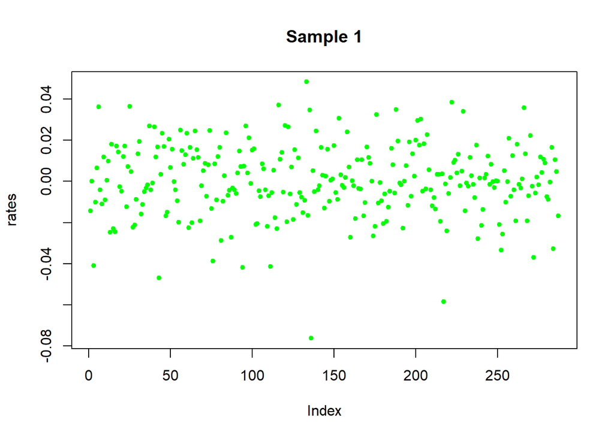

```r
plot(rates,type = 'p',pch = 20,col = "green",main = "Sample 1")
```

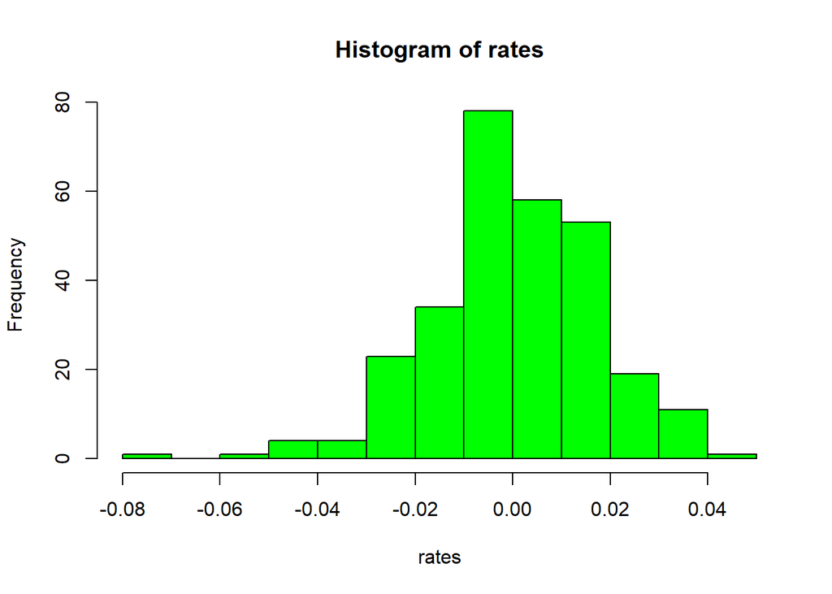

```r
hist(rates,col = 'green',lwd = 1)
```

## В целом в первом приближении можно считать распределение нормальным с нулевым средним и средним отклонением около 0.02

Давайте сравним с графиками такого распределения:

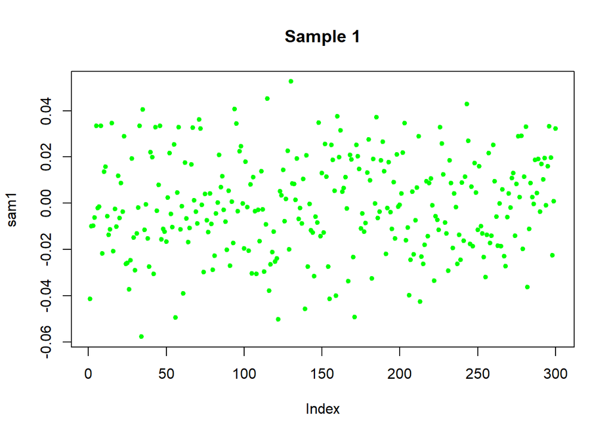

```r
n<-300
mu <- 0
sigma<- 0.02
sam1 <- rnorm(n,mu,sigma)
plot(sam1,type = 'p',pch = 20,col = "green",main = "Sample 1")
```

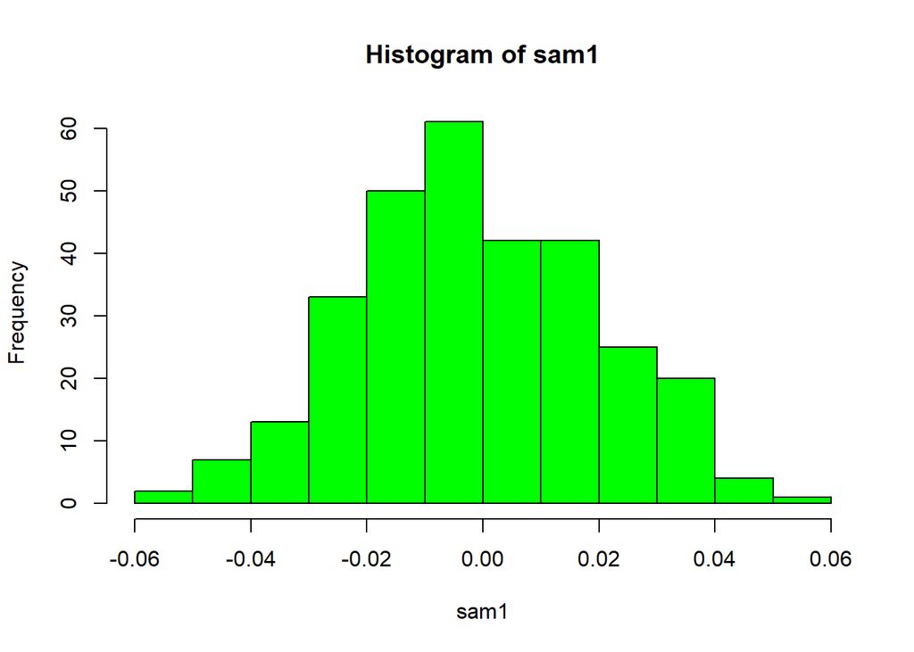

```r
hist(sam1,col = 'green',lwd = 1)
```

Выглядит адекватно: хвосты убывают так же быстро, частоты примерно совпадают, только вот у исходного распределения доходностей нет такой симметрии относительно нуля, там больше отрицательных по модулю небольших доходностей в районе 1 процента и не так много положительных доходностей в районе 1 процента, они распределены более равномерно по одному-двум процентам

## Разделим случайно выборку на две части: тренировочную и тестовую

```r
d = sort(sample(n, n * 0.5))
train<-rates[-d]
test<-rates[d]
```

Методом максимального правдоподобия оценим параметры предполагаемого распределения по тренировочной части выборки:

```r
library(fitdistrplus)
fin <- fitdist(train,"norm")
fin
```

```
## Fitting of the distribution ' norm ' by maximum likelihood
## Parameters:
##         estimate   Std. Error
## mean 0.001254495 0.0013056347
## sd   0.015558433 0.0009061183
```

Или эквивалентным способом:

```r
library(MASS)
fitting_normal<-fitdistr(train,"normal")
fitting_normal
```

```
##        mean            sd
##   0.0012544951   0.0155584332
##  (0.0013056347) (0.0009232232)
```

```r
mu <- fitting_normal$estimate[[1]]
sigma <- fitting_normal$estimate[[2]]
```

## Проверим гипотезу согласия с предложенным распределением на всей выборке критерием Колмогорова-Смирнова

```r
 ks.test(rates,'pnorm',mu,sigma)
```

```
##
##  Asymptotic one-sample Kolmogorov-Smirnov test
##
## data:  rates
## D = 0.052842, p-value = 0.3994
## alternative hypothesis: two-sided
```

P-Value больше 0.05, следовательно гипотеза нормальности с такими параметрами не отвергается

## Проверим гипотезу согласия с предложенным распределением на всей выборке критерием Хи-квадрат Пирсона

```r
library(zoo)
```

```r
h <- hist(rates,plot = F)
(E <- h$breaks)
```

```
##  [1] -0.08 -0.07 -0.06 -0.05 -0.04 -0.03 -0.02 -0.01  0.00  0.01  0.02  0.03
## [13]  0.04  0.05
```

```r
n = length(rates)
 (dens <- h$density * n * .01)
```

```
##  [1]  1  0  1  4  4 23 34 78 58 53 19 11  1
```

```r
breaks_cdf <- pnorm(E, mu, sigma)
null.probs <- rollapply(breaks_cdf,2, function(x) x[2]-x[1])
null.probs
```

```
##  [1] 2.238872e-06 3.891577e-05 4.520535e-04 3.512461e-03 1.827098e-02
##  [6] 6.367585e-02 1.487739e-01 2.331412e-01 2.451108e-01 1.728900e-01
## [11] 8.180021e-02 2.594993e-02 5.516404e-03
```

```r
sum(null.probs)
```

```
## [1] 0.9991349
```

```r
xsq <- chisq.test(x = dens,p = null.probs,rescale.p= T)
xsq$p.value
```

```
## [1] 0
```

P-Value меньше 0.05, следовательно гипотеза нормальности с такими параметрами отвергается